# 离心的书

```python
import pandas as pd
import numpy as np
import matplotlib.pyplot as plt
import seaborn as sns
import re
import os
from collections import defaultdict
import warnings

from dash import Dash, dcc, html, Input, Output
import plotly.express as px
from pylab import *
from pyecharts.charts import *
from pyecharts.charts import Pie, Bar, MapGlobe
from pyecharts.faker import POPULATION
from pyecharts.commons.utils import JsCode
from pyecharts.globals import ChartType, ThemeType
import pyecharts.options as opts
from plotly.offline import init_notebook_mode
init_notebook_mode(connected=True)

warnings.filterwarnings('ignore')
```

```python
data = pd.read_csv("./dataset/owid-co2-data.csv")
co2_per_capita = data[['country', 'year', 'co2_per_capita']]
country_names = [x for x, _ in POPULATION[1:]]
co2_per_capita_2020 = co2_per_capita[co2_per_capita['year'] == 2020].fillna(0)

def longestCommonSubstr(word1: str, word2: str) -> int:
    m = len(word1)
    n = len(word2)
    dp = [[0] * (n + 1) for _ in range(m + 1)]
    # dp[i][j]代表word1以i结尾,word2以j结尾，的最大公共子串的长度

    max_len = 0
    row = 0
    col = 0
    for i in range(1, m + 1):
        for j in range(1, n + 1):
            if word1[i - 1] == word2[j - 1]:
                dp[i][j] = dp[i - 1][j - 1] + 1
                if max_len < dp[i][j]:
                    max_len = dp[i][j]
                    row = i
                    col = j

    max_str = ""
    i = row
    j = col
    while i > 0 and j > 0:
        if dp[i][j] == 0:
            break
        i -= 1
        j -= 1
        max_str += word1[i]

    lcstr = max_str[::-1]
    # 回溯的得到的最长公共子串
    return max_len


def fuzzy_match(src_str: str, dst_str: str) -> bool:
    match_len = longestCommonSubstr(src_str, dst_str)
    return match_len > len(src_str) * 0.75


def search(target_str: str, data: pd.DataFrame) -> float:
    for idx, row in data.iterrows():
        if fuzzy_match(target_str, row['country']):
            return row['co2_per_capita']
    return 0.0


data_pair_2020 = POPULATION[1:]
# 模糊匹配国家名
data_pair_2020 = [[country, search(country, co2_per_capita_2020)] for country, _ in data_pair_2020]
value_2020 = [x for _, x in data_pair_2020]
low_2020, high_2020 = min(value_2020), max(value_2020)
#底色改为蓝色
figure_2020 = MapGlobe(init_opts=opts.InitOpts(bg_color="#63B5FF"))
figure_2020 = figure_2020.add_schema()
figure_2020 = figure_2020.add(maptype="world", series_name="World Population", data_pair=data_pair_2020,
                              is_map_symbol_show=False, label_opts=opts.LabelOpts(is_show=False), )
#修改各个国家的颜色
figure_2020 = figure_2020.set_series_opts(label_opts=opts.LabelOpts(is_show=False), itemstyle_opts={
    "normal": {"areaColor": "#FFEDCB", "borderColor": "#3E4756", "borderWidth": 1.1},
    "emphasis": {"areaColor": "#8C1F4E"} })
figure_2020 = figure_2020.set_global_opts(title_opts=opts.TitleOpts(title="2020年世界各国碳排放总量"),
                                          visualmap_opts=opts.VisualMapOpts(min_=0, max_=10, range_text=["max", "min"],
                                                                            is_calculable=True,range_color=["lightskyblue", "yellow","orangered"], ))

# figure_2020.render("2020年世界各国碳排放总量.html")
figure_2020.render_notebook()
```

[output not shown]

# 论点1 谁的责任？

发展中国家or发达国家or both？

以美国为首的发达国家主张应按照一个国家碳排放量对全球气候变化产生的影响程度决定减少排放责任的大小

以中国为首的发展中国家侧重主张已经实现向低碳经济“华丽转身”的发达国家不能将其历史上排放累积所造成的结果一笔勾销, 而应据此承担减排的历史责任。

于是我们做了部分发达国家和发展中国家从1950年~2020年的碳排放曲线图。

如图所示，发达国家历史碳排高，发展中国家近年碳排高，问题看似确实如此。

```python
df = pd.read_csv('./dataset/owid-co2-data.csv', encoding='utf-8')
datasize = len(df)
data1 = {}
contry_name = ['China', 'India', 'Brazil', 'Russia', 'South Africa', 'United States',
               'United Kingdom', 'France', 'Germany', 'Japan']


def get_answer(i, year):
    for j in range(i, datasize):
        if (int(df.iat[j, 2]) == year):
            return float(df.iat[j, 3])


for name in contry_name:
    for i in range(1, datasize):
        #找到对应国家
        temp = []
        if (str(df.iat[i, 1]) == name):
            for a in range(1950, 2021):
                temp.append(get_answer(i, a))
            data1[name] = temp
            break
# data1
work = pd.DataFrame(data1, index=[i + 1950 for i in range(2021 - 1950)])
# work
x = [i + 1950 for i in range(2021 - 1950)]
y2 = data1['China']
y3 = data1['United States']
y4 = data1['Russia']
y5 = data1['India']
```

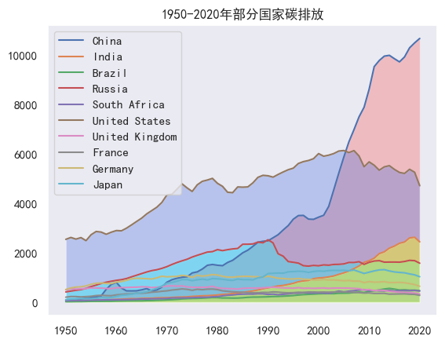

```python
mpl.rcParams['font.sans-serif'] = ['SimHei']
plt.plot(work)
plt.legend(labels=contry_name)
plt.fill_between(x=x, y1=0, y2=y2, facecolor='red', alpha=0.2)
plt.fill_between(x=x, y1=0, y2=y3, facecolor='royalblue', alpha=0.3)
plt.fill_between(x=x, y1=0, y2=y4, facecolor='cyan', alpha=0.3)
plt.fill_between(x=x, y1=0, y2=y5, facecolor='yellow', alpha=0.4)
plt.title("1950-2020年部分国家碳排放")
plt.show()
```

碳排放少是否等于碳消费低？答案显然是否定的。

我们做了近年的世界各国的人均碳生产和碳消费的玫瑰图。

发现大部分国家符合特征：人均碳生产高的国家人均碳消费低（蓝色部分显著长），人均碳生产低的国家人均碳消费反而高（橙色部分显著长）。

究其原因，发达国家将有碳生产过程放给发展中国家做，自己享用碳消费成品。

```python
def find_name(id):
    for i in range(1, datasize):
        if (df.iat[i, 0] == id):
            return str(df.iat[i, 1])
    return "nan"


df2 = pd.read_csv('./dataset/data2.csv', encoding='utf-8')
size2 = len(df2)
third_data = {}
for i in range(1, datasize):
    if (str(df.iat[i, 2]) == "2020"):
        temp = []
        temp.append(float(df.iat[i, 8]))
        third_data[str(df.iat[i, 1])] = temp
for i in range(1, size2):
    third_id = df2.iat[i, 1]
    third_name = find_name(third_id)
    if (third_data.get(third_name) != None):
        third_data[third_name].append(float(df2.iat[i, 60]))
        if (len(third_data[third_name]) > 2):
            del third_data[third_name][2:-1]
            del third_data[third_name][-1]
temp_name = []
for i in third_data:
    if (len(third_data[i]) < 2):
        temp_name.append(i)
    if (str(third_data[i][0]) == "nan"):
        temp_name.append(i)
for i in temp_name:
    if (third_data.get(i) != None):
        third_data.pop(i)
for i in third_data:
    if (str(third_data[i][1]) == "nan"):
        third_data[i][1] = 0
for i in third_data:
    temp_number = third_data[i][0]
    if (third_data[i][1] != 0):
        third_data[i][0] = temp_number * third_data[i][1] / 100
    third_data[i][1] = temp_number - third_data[i][0]
third_work = pd.DataFrame(third_data, index=["碳生产", "碳消费"])
N = third_work.shape[1]
theta = np.linspace(0, 2 * np.pi, N, endpoint=False)
width = np.pi / N
labels = list(third_work.columns)
```

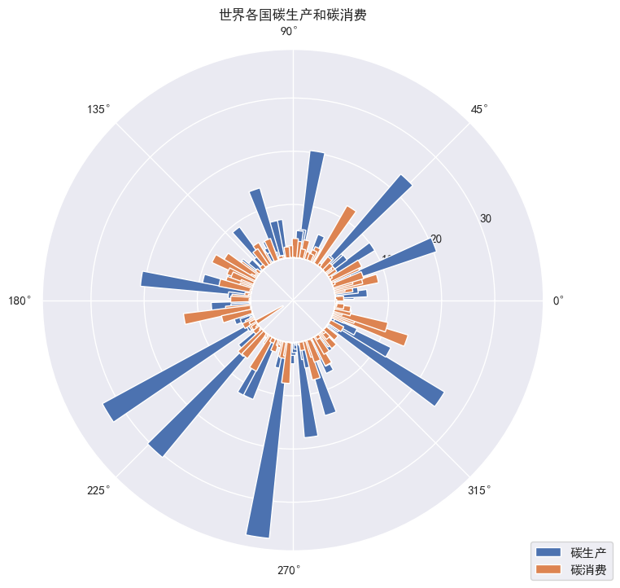

```python
mpl.rcParams['font.sans-serif'] = ['SimHei']
plt.figure(figsize=(8, 8))
ax = plt.subplot(111, projection='polar')
for idx in third_work.index:
    # 每一行绘制一个扇形
    radii = third_work.loc[idx]  # 每一行数据
    ax.bar(theta, radii, width=0.1, bottom=0.0, label=idx)
plt.legend(loc=4, bbox_to_anchor=(1.15, -0.07))
plt.title("世界各国碳生产和碳消费")
plt.show()
```

```python
data = pd.read_csv("./dataset/owid-co2-data.csv")
merged_info = pd.read_csv("./dataset/mergedinfo.csv")
country_names = merged_info.loc[:,'Name']
data = data[['country', 'year', 'consumption_co2', 'cumulative_co2', 'co2']].set_index('country')
data =  data[data['year'] == 2020].fillna(0)
data['consumption_co2'] = data['co2'] - data['cumulative_co2']

omit_rate = 1

consumption_data = [[country, data.loc[country, 'co2']] for country in country_names if country in data.index]
consumption_value = [x for _, x in consumption_data]
mean_value = np.mean(consumption_value)
consumption_data_ = [ele for ele in consumption_data if ele[1] >= mean_value * omit_rate]
consumption_data_.append(['other countries', np.sum([ele[1] for ele in consumption_data if ele[1] < mean_value * omit_rate])])

production_data = [[country, data.loc[country, 'cumulative_co2']] for country in country_names if country in data.index]
production_value = [x for _, x in production_data]
mean_value = np.mean(production_value)
production_data_ = [ele for ele in production_data if ele[1] >= mean_value * omit_rate]
production_data_.append(['other countries', np.sum([ele[1] for ele in production_data if ele[1] < mean_value * omit_rate])])
```

```python
figure = Pie()
figure = figure.add("", data_pair = production_data_, radius=["30%", "75%"], center=["25%", "50%"],
                   rosetype="radius", label_opts=opts.LabelOpts(is_show=False))
figure = figure.add("", data_pair = consumption_data_, radius=["30%", "75%"], center=["75%", "50%"],
                   rosetype="radius", label_opts=opts.LabelOpts(is_show=False))
figure = figure.set_global_opts(title_opts=opts.TitleOpts(title="发展中国家和发达国家碳消费和碳生产指数"), legend_opts=opts.LegendOpts(pos_bottom='0%'))
figure.render_notebook()
```

[output not shown]

```python
data5 = {}
df2 = pd.read_csv('./dataset/mergedinfo.csv', encoding='utf-8')
datasize2 = len(df2)


def get_answer3(name):
    for i in range(1, datasize):
        if (str(df.iat[i, 1]) == name and int(df.iat[i, 2]) == 2020):
            return float(df.iat[i, 8])
    return 0


for i in range(1, datasize2):
    temp = []
    temp.append(float(df2.iat[i, 2]))
    temp.append(float(df2.iat[i, 3]))
    temp.append(get_answer3(str(df2.iat[i, 0])))
    data5[str(df2.iat[i, 0])] = temp
# data5
```

```python
def map3d_world_base() -> Map3D:
    example_data = []
    for i in data5:
        temp = (i, data5[i])
        example_data.append(temp)

    c = (
        Map3D()
        .add_schema(
            maptype='world',
            itemstyle_opts=opts.ItemStyleOpts(
                color="rgb(121,101,123)",
                opacity=1,
                border_width=0.8,
                border_color="rgb(62,215,213)",
            ),
            map3d_label=opts.Map3DLabelOpts(
                is_show=True,
                text_style=opts.TextStyleOpts(
                    color="#fff", font_size=16, background_color="rgba(0,0,0,0)"
                ),
            ),
            emphasis_label_opts=opts.LabelOpts(is_show=True),
            light_opts=opts.Map3DLightOpts(
                main_color="#fff",
                main_intensity=1.2,
                is_main_shadow=False,
                main_alpha=55,
                main_beta=10,
                ambient_intensity=0.3,
            ),
        )
        .add(series_name="bar3D", data_pair=example_data, type_=ChartType.BAR3D,
             is_animation=True,
             bar_size=1, shading="realistic", label_opts=opts.LabelOpts(
                is_show=False,
                formatter=JsCode(
                    "function(data){return data.name + ' ' + data.value[2];}"
                ),
            )
             )
        .set_global_opts(
            title_opts=opts.TitleOpts(title="世界各国碳排放柱状图"),
            visualmap_opts=opts.VisualMapOpts(is_show=True),
            tooltip_opts=opts.TooltipOpts(is_show=True),
        )
        .render_notebook()
        # .render("世界各国碳排放柱状图.html")
    )
    return c


map3d_world_base()
```

[output not shown]

基于以上初步分析，我们认为，当我们摈弃仅仅从碳生产衡量各国责任的思维，而是从更加全面的角度出发，发达国家和发展中国家应承担同样的气候变化和减排的责任。

```python
inner_x_data = ["发展中国家", "发达国家"]
inner_y_data = [29.807, 39.171]
inner_data_pair = [list(z) for z in zip(inner_x_data, inner_y_data)]

outer_x_data = ["中国", "印度", "巴西", "俄罗斯", "南非", "美国", "英国", "法国", "德国", "日本"]
outer_y_data = [7.412, 1.769, 2.199, 10.807, 7.62, 14.238, 4.855, 4.238, 7.69, 8.15]
outer_data_pair = [list(z) for z in zip(outer_x_data, outer_y_data)]

(
    Pie(init_opts=opts.InitOpts(width="1000px", height="600px"))
    .add(
        series_name="人均排放量",
        data_pair=inner_data_pair,
        radius=[0, "30%"],
        label_opts=opts.LabelOpts(position="inner"),
    )
    .add(
        series_name="人均排放量",
        radius=["40%", "55%"],
        data_pair=outer_data_pair,
        label_opts=opts.LabelOpts(
            position="outside",
            formatter="{a|{a}}{abg|}\n{hr|}\n {b|{b}: }{c}  {per|{d}%}  ",
            background_color="#eee",
            border_color="#aaa",
            border_width=1,
            border_radius=4,
            rich={
                "a": {"color": "#999", "lineHeight": 22, "align": "center"},
                "abg": {
                    "backgroundColor": "#f3e3e3",
                    "width": "100%",
                    "align": "right",
                    "height": 22,
                    "borderRadius": [4, 4, 0, 0],
                },
                "hr": {
                    "borderColor": "#aaa",
                    "width": "100%",
                    "borderWidth": 0.5,
                    "height": 0,
                },
                "b": {"fontSize": 16, "lineHeight": 33},
                "per": {
                    "color": "#eee",
                    "backgroundColor": "#336455",
                    "padding": [2, 4],
                    "borderRadius": 2,
                },
            },
        ),
    )
    .set_global_opts(
        legend_opts=opts.LegendOpts(pos_left="left", orient="vertical"),
        title_opts=opts.TitleOpts(title='部分国家人均碳排放量', pos_left="center", pos_right="center")
    )
    .set_series_opts(
        tooltip_opts=opts.TooltipOpts(
            trigger="item", formatter="{a} <br/>{b}: {c} ({d}%)"
        )
    )
    .render_notebook()
    # .render("部分国家人均碳排放量.html")
)
```

[output not shown]

# 论点2: 春风又绿 GDP，Responsibility!

发展是离不开碳排，这是人类经济社会的基本规律，从下面一张主要国家的二氧化碳和 GDP 的动态散点图可以看出，所有散点都在往平面的右上方运动，这恰恰印证碳排放的增加就是发展的代价之一。

```python
contry_name=['China','India','Brazil','Russia','South Africa','United States', 'United Kingdom','France','Germany','Japan']
year_selected = list(range(1901, 2021, 10))
year_selected += [2020]
df = pd.read_csv("./dataset/owid-co2-data.csv")
df2 = df.loc[df['country'].isin(contry_name)]
df3 = df2.fillna(method='ffill')
df4 = df3.loc[df3['year'].isin(year_selected)]
```

```python
px.scatter(
    df4,
    x="co2",
    y="gdp",
    animation_frame="year",
    animation_group="country",
    size="population",
    color="country",
    hover_name="country",
    log_x=True,
    size_max=40,
    range_x=[1, 14000],
    range_y=[-1e13 * 0.3, 1e13 * 2 + 1e12 * 3]
).show()
```

[interactive chart not shown]

众所周知，发展离不开碳排，但我们又不能不发展，所以我们不能剥离开经济发展光谈碳排放量。

于是我们考虑单位发展进度过程中的碳排放，以权衡二者。做出了单位 GDP 过程中的碳排放图，用 GDP 来表征发展进度。

根据曲线图和小提琴图显示，发达国家和发展中国家单位 GDP 所产生的碳排放在不断趋同，至今已高度相似。

```python
# 读入数据，加入developed列
info = pd.read_csv('./dataset/mergedinfo.csv')
info.set_index('Name', inplace=True)
developed = info['Developed'].apply(lambda x: 'developed' if x else 'developing').to_dict()
developed = defaultdict(lambda: np.nan, developed)
ggdp = pd.read_excel('./dataset/greenGDP.xlsx', sheet_name='Green')
ggdp['developed'] = ggdp['Country Name'].apply(lambda x: developed[x])
ggdp.dropna(subset=['developed'], inplace=True)
gdp = pd.read_excel('./dataset/greenGDP.xlsx', sheet_name='gdp')
gdp['developed'] = gdp['Country Name'].apply(lambda x: developed[x])
gdp.dropna(subset=['developed'], inplace=True)
co2 = pd.read_excel('./dataset/greenGDP.xlsx', sheet_name='co2')
co2['developed'] = co2['Country Name'].apply(lambda x: developed[x])
co2.dropna(subset=['developed'], inplace=True)
co2_consumption = pd.read_csv('./dataset/owid-co2-data.csv')
co2_consumption['developed'] = co2_consumption['country'].apply(lambda x: developed[x])
co2_consumption.dropna(subset=['developed'], inplace=True)
co2_consumption = co2_consumption[co2_consumption['year'] >= 1950]
pop = pd.read_csv('./dataset/population_data.csv')
pop['developed'] = pop['name'].apply(lambda x: developed[x])
pop.dropna(subset=['developed'], inplace=True)
pop = pop.groupby(['Year', 'developed']).sum()
sns.set_style('darkgrid')
```

```python
# 分别提取
year = ggdp.columns[2:-1].astype(int)
ggdp_developed = ggdp[ggdp['developed'] == 'developed'].iloc[:, 2:-1].mean(axis=0)
ggdp_developing = ggdp[ggdp['developed'] == 'developing'].iloc[:, 2:-1].mean(axis=0)
gdp_developed = gdp[gdp['developed'] == 'developed'].iloc[:, 2:-1].mean(axis=0)
gdp_developing = gdp[gdp['developed'] == 'developing'].iloc[:, 2:-1].mean(axis=0)
# 集中到一张表中
data_developed = pd.DataFrame({'year': year,
                               'gdp': gdp_developed,
                               'ggdp': ggdp_developed,
                               'ggdp/gdp': ggdp_developed / gdp_developed,
                               'developed': 'developed',
                               'pop': pop.loc[pd.IndexSlice[1970:2019, 'developed', :]].values.flatten(),
                               })
data_developing = pd.DataFrame({'year': year,
                                'gdp': gdp_developing,
                                'ggdp': ggdp_developing,
                                'ggdp/gdp': ggdp_developing / gdp_developing,
                                'developed': 'developing',
                                'pop': pop.loc[pd.IndexSlice[1970:2019, 'developing', :]].values.flatten(),
                                })
data = pd.concat([data_developing, data_developed], axis=0)
# GGDP 各因素汇总表
dataset = pd.DataFrame()
for sheet in ['Green', 'gdp', 'waste', 'natural', 'co2', 'gni']:
    tmp = pd.read_excel('./dataset/greenGDP.xlsx', sheet_name=sheet)
    id_vars = set(['Country Name', 'Indicator Name']).intersection(set(tmp.columns))
    tmp['Indicator Name'] = sheet
    tmp = tmp.melt(id_vars=id_vars)
    tmp['variable'] = tmp['variable'].apply(lambda x: re.sub(r'\D', '', x))
    tmp = tmp.rename(columns={'variable': 'year'})
    dataset = pd.concat([dataset, tmp], axis=0)

values = dataset.groupby(['Indicator Name', 'year'])['value'].mean()
values = values.reset_index().pivot(index='year', columns='Indicator Name', values='value')
values['ggdp/gdp'] = values['Green'] / values['gdp']
# sns.pairplot(values)
```

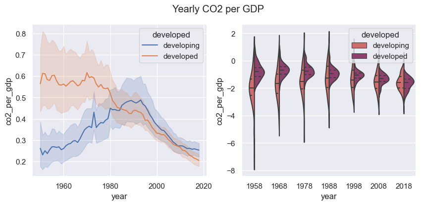

```python
co2_consumption_violin = co2_consumption[co2_consumption['year'] % 10 == 8].copy()
co2_consumption_violin.loc[:, 'co2'] = co2_consumption_violin['co2'].apply(lambda x: np.log(x))
fig, axes = plt.subplots(1, 2, figsize=(10, 4))
sns.lineplot(x='year', y='co2_per_gdp', hue='developed', data=co2_consumption, ax=axes[0])
co2_consumption_violin.loc[:, 'co2_per_gdp'] = co2_consumption_violin['co2_per_gdp'].apply(lambda x: np.log(x))
sns.violinplot(x='year',
               y='co2_per_gdp',
               hue='developed',
               data=co2_consumption_violin,
               ax=axes[1],
               split=True,
               palette='flare',
               inner="quartile", )
fig.suptitle('Yearly CO2 per GDP')
```

另外，单位碳排放所使用的燃料不同，对环境产生的危害也不同。

于是我们做了部分国家的能源结构图，发现大家的能源结构差异很大。

有的国家主要使用煤炭等污染较为严重的燃料；有的则主要使用天然气等较为清洁的燃料。

```python
df = pd.read_csv("./dataset/owid-co2-data.csv")
data2 = {}


def get_answer2(i):
    temp = []
    for a in range(i, datasize):
        if (int(df.iat[a, 2]) == 2020):
            for j in range(16, 21):
                temp.append(float(df.iat[a, j]))
            return temp


for name in contry_name:
    for i in range(1, datasize):
        #找到对应国家
        if (str(df.iat[i, 1]) == name):
            data2[name] = get_answer2(i)
            break
co2_type = ['coal', 'cement', 'flaring', 'gas', 'oil']
data3 = {}
for i in range(5):
    temp = []
    for j in contry_name:
        if (str(data2[j][i]) != "nan"):
            temp.append(data2[j][i])
        else:
            temp.append(0)
    data3[co2_type[i]] = temp
data3['country'] = contry_name
temp_data = []
for i in range(10):
    temp = 0
    for j in co2_type:
        temp += data3[j][i]
    temp_data.append(temp)
data3['sum'] = temp_data
work2 = pd.DataFrame(data3)
# work2
df_group = work2.groupby('country').sum()
for i in co2_type:
    df_group['{}_Percent'.format(i)] = df_group[i] / df_group['sum']
df_group = df_group.sort_values('coal_Percent', ascending=False)
# df_group
```

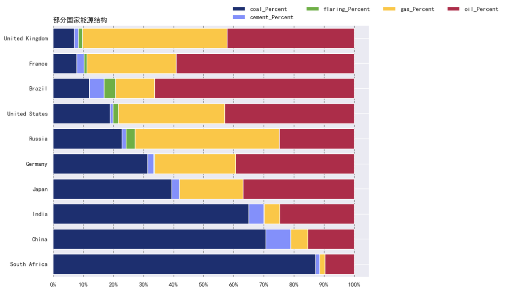

```python
mpl.rcParams['font.sans-serif'] = ['SimHei']
color = ['#1D2F6F', '#8390FA', '#6EAF46', '#FAC748', '#AC2D49']
co2_type = ['coal_Percent', 'cement_Percent', 'flaring_Percent', 'gas_Percent', 'oil_Percent']
fig, ax = plt.subplots(1, figsize=(10, 8))
left = len(df_group) * [0]
for idx, name in enumerate(co2_type):
    plt.barh(df_group.index, df_group[name], left=left, color=color[idx])
    left = left + df_group[name]
plt.title('部分国家能源结构', loc='left')
plt.legend(co2_type, bbox_to_anchor=([0.55, 1, 0, 0]), ncol=4, frameon=False)
#横坐标
xticks = np.arange(0, 1.1, 0.1)
xlabels = ['{}%'.format(i) for i in np.arange(0, 101, 10)]
plt.xticks(xticks, xlabels)
#去除spines
ax.spines['right'].set_visible(False)
ax.spines['left'].set_visible(False)
ax.spines['top'].set_visible(False)
ax.spines['bottom'].set_visible(False)
plt.ylim(-0.5, ax.get_yticks()[-1] + 0.5)
ax.set_axisbelow(True)
ax.xaxis.grid(color='gray', linestyle='dashed')
plt.show()
```

所以我们考虑将对环境污染程度加入考量指标中。于是我们关注了一种新兴的评估指标——绿色GDP。GreenGDP，简称GGDP，等于 GDP 减去资源消耗、环境污染、CO2排放等的代价，再加上保护生态，发现或开发可持续的资源等的收益。其可以很好地反应在综合环境因素的影响下，可持续经济发展的真实情况。而用 GGDP 除以 GDP 得到的比值就可以反应一个国家经济的绿色状况，为了方便以下简称绿色率。以下我们就从绿色GDP相关的概念入手，论证“发达国家和发展中国家应承担同样的气候变化和减排的责任”。

数据来自2022年的一篇最新论文：A new database on Green GDP; 1970–2019: a framework for assessing the green economy。

首先，观察历年来发展中国家和发达国家的平均绿色率变化趋势，可以明显看到，在大约1990年之后，发达国家的绿色率就维持在 99% 的水平上停滞不前了，而发展中国家的绿色率则在不断上升，到了2019年，发展中国家的绿色率已经达到了 97% 了，相比于过去，这个差距已经非常小了，而且发展中国家的绿色率上升的趋势仍然十分明显，根据趋势越策很快就会趋同。

所以发展中国家和发达国家之间的绿色差距，并没有我们想象得那么高。他们需要承担的责任自然一致

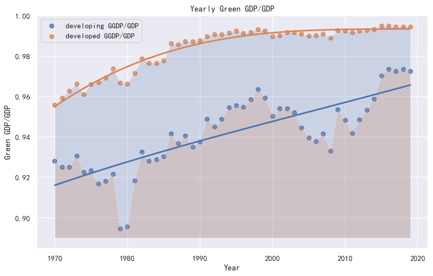

```python
plt.figure(figsize=(10, 6))
sns.regplot(x=year,
            y=ggdp_developing / gdp_developing,
            label='developing GGDP/GDP',
            order=3,
            # logistic=True,
            ci=0,
            )
sns.regplot(x=year,
            y=ggdp_developed / gdp_developed,
            label='developed GGDP/GDP',
            order=3,
            # logistic=True,
            ci=0,
            )
plt.fill_between(year, ggdp_developed / gdp_developed, 0.89, alpha=0.2)
plt.fill_between(year, ggdp_developing / gdp_developing, 0.89, alpha=0.2)
plt.title('Yearly Green GDP/GDP')
plt.ylabel('Green GDP/GDP')
plt.xlabel('Year')
plt.legend()
```

更重要的是，从这个关系中我们可以发现，帮助发展中国家发展能够产生的边际环境效益是十分显著的。

就像一个经典的博弈模型智猪博弈一样，对发达国家来说，其最经济的选择事实上就是帮助发展中国家减排，这事实上是对发达和发展国家来说的最优解。

当然，发展中国家也要积极寻求帮助。也就是，二者合作，共同承担，才是最优解。

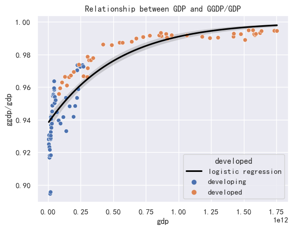

```python
ax = sns.regplot(x='gdp',
                 y='ggdp/gdp',
                 data=data,
                 logistic=True,
                 scatter=False,
                 color='black',
                 label='logistic regression',
                 )

sns.scatterplot(x='gdp',
                y='ggdp/gdp',
                hue='developed',
                data=data,
                ax=ax)

ax.set_title('Relationship between GDP and GGDP/GDP')
```

以上是历史数据，那么观察今日之世界，可以看到很多国家无论发展中或发达，已经集中在重叠的区域里。

经过以上细致地分析，更加佐证了我们的观点，发达国家和发展中国家的责任是相同的。

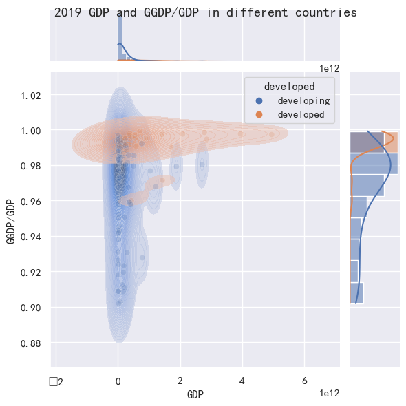

```python
d1 = ggdp.loc[:, ['Country Name', '2018', 'developed']]
d2 = gdp.loc[:, ['Country Name', '2018', 'developed']]
d3 = co2.loc[:, ['Country Name', '2018', 'developed']]
d = pd.merge(d1, d2, on=['Country Name', 'developed'], suffixes=('_ggdp', '_gdp'))
d = pd.merge(d, d3, on=['Country Name', 'developed'])
d.rename(columns={'2018_ggdp': 'ggdp', '2018_gdp': 'gdp', '2018': 'co2'}, inplace=True)
d['ggdp/gdp'] = d['ggdp'] / d['gdp']

# 去除偏离很大的点，可以更好反应出大部分国家的情况
arg = (d['gdp'] < 1e13) & (d['ggdp/gdp'] > 0.9)
d = d[arg]

g = sns.JointGrid(x='gdp', y='ggdp/gdp', data=d, hue='developed')
g.plot_joint(sns.kdeplot, fill=True, levels=50, alpha=0.5)
g.plot_joint(sns.scatterplot, alpha=0.2)
g.plot_marginals(sns.histplot, kde=True, color='black')
g.set_axis_labels('GDP', 'GGDP/GDP')
g.figure.suptitle('2019 GDP and GGDP/GDP in different countries')
```

# 论点3：如何合作？

在减排护球的历程中，**科技发挥着至关重要的意义**。我们依据创新指数度量科技发展水平，绘制了单位GDP碳排与科技水平关系的散点图。 图像中点的面积代表GDP总量，图中散点面积较小的国家标志着国家面积较小或工业化水平较低，抛却这些小微国家，我们看到，**世界上已完成工业化的主要大国的单位GDP碳排与科技发展水平呈现出明显的相关关系**。除此之外，我们还可以得到两个结论：

- 即使是部分科技发展极为落后的国家，通过发展可持续能源，也能实现降低碳排的目的，对于这些国家，我们只需在他们工业化之时加以干预，目前无需担忧他们的碳排放问题。
- **对于部分高速发展的但科技发展水平不高的发展中国家，目前急需提高科技发展水平以实现减排任务**。

```python
warnings.filterwarnings('ignore')


def clean_country(df: pd.DataFrame, col: str):
    df[col] = df[col].str.replace('Burma \(now Myanmar\)', 'Myanmar', regex=True)
    df[col] = df[col].str.replace('.*Pakistan.*', 'Pakistan', regex=True)
    df[col] = df[col].str.replace('.*Austria.*', 'Austria', regex=True)
    df[col] = df[col].str.replace('.*Israel.*', 'Israel', regex=True)
    df[col] = df[col].str.replace('USA', 'United States', regex=True)
    df[col] = df[col].str.replace('.*Germany.*', 'Germany', regex=True)
    df[col] = df[col].str.replace('.*Italy.*', 'Italy', regex=True)
    df[col] = df[col].str.replace('.*Algeria.*', 'Algeria', regex=True)
    df[col] = df[col].str.replace('.*Russia.*', 'Russia', regex=True)
    df[col] = df[col].str.replace('.*China.*', 'China', regex=True)
    df[col] = df[col].str.replace('.*Netherlands.*', 'Netherlands', regex=True)
    df[col] = df[col].str.replace('.*Ireland.*', 'United Kingdom', regex=True)
    df[col] = df[col].str.replace('.*Scotland.*', 'United Kingdom', regex=True)
    df[col] = df[col].str.replace('Czechoslovakia \(now Czech Republic\)', 'Czech Republic', regex=True)
    df[col] = df[col].str.replace('Austria-Hungary \(now Czech Republic\)', 'Czech Republic', regex=True)
    df[col] = df[col].str.replace('.*Poland.*', 'Poland', regex=True)
    df[col] = df[col].str.replace('.*Zimbabwe.*', 'Zimbabwe', regex=True)
    df[col] = df[col].str.replace('.*South Korea.*', 'South Korea', regex=True)
    df[col] = df[col].str.replace('.*Timor.*', 'Timor-Leste', regex=True)
    df[col] = df[col].str.replace('.*Iran.*', 'Iran', regex=True)
    df[col] = df[col].str.replace('.*IT.*', 'Italy', regex=True)
    df[col] = df[col].str.replace('.*Denmark.*', 'Denmark', regex=True)
    df[col] = df[col].str.replace('.*Macedonia.*', 'Macedonia, FYR', regex=True)
    df[col] = df[col].str.replace('.*Belarus.*', 'Belarus', regex=True)
    df[col] = df[col].str.replace('.*Indonesia.*', 'Indonesia', regex=True)
    df[col] = df[col].str.replace('.*India.*', 'India', regex=True)
    df[col] = df[col].str.replace('.*Lucia.*', 'St. Lucia', regex=True)
    df[col] = df[col].str.replace('.*Bosnia.*', 'Bosnia and Herzegovina', regex=True)
    df[col] = df[col].str.replace('.*Trinid.*', 'Trinidad and Tobago', regex=True)
    return df
```

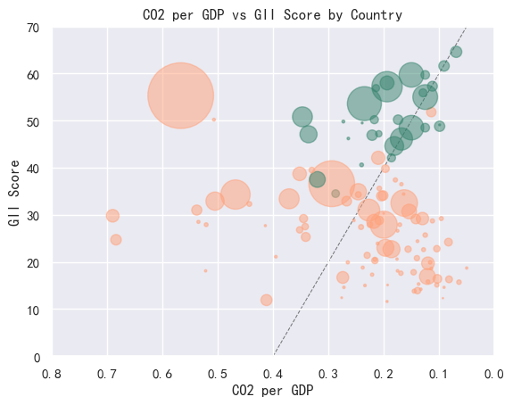

```python
co2_df = pd.read_csv("./dataset/owid-co2-data.csv")
clean_country(co2_df, 'country')
co2_per_gdp_df = co2_df[['country', 'co2_per_gdp', 'gdp', 'co2']][co2_df['year'] == 2018]
gii_df = pd.read_csv('./dataset/GII.csv')
clean_country(gii_df, 'Economy')
developed_countries = ['Ireland', 'France', 'Netherlands', 'Belgium', 'Luxembourg', 'Germany', 'Austria', 'Switzerland',
                       'Norway', 'Iceland', 'Denmark', 'Sweden', 'Finland', 'Italy', 'Spain', 'Portugal',
                       'Greece', 'Slovenia', 'Czech Republic', 'Slovak Republic', 'Malta', 'Cyprus', 'United States',
                       'United Kingdom',
                       'Canada', 'New Zealand', 'Poland', 'Australia', 'Japan', 'Singapore', 'South Korea', 'Israel']
#如果是发达国家，在图中颜色变成红色 否则变成蓝色
co2_per_gdp_df['color'] = co2_per_gdp_df['country'].apply(
    lambda x: '#37846E' if x in developed_countries else '#FFA17A')

# 合并数据
merged_df = pd.merge(co2_per_gdp_df, gii_df, left_on='country', right_on='Economy')
merged_df.sort_values(by='co2_per_gdp', inplace=True)
merged_df.to_csv('./dataset/merged_df.csv')
lat_lon_df = pd.read_csv('./dataset/longitude_and_latitude.csv')
# 绘制散点图,标记发达国家和发展中国家,并标记国家名称,x坐标轴从0.4到1.2,y坐标轴从0到1
x = np.linspace(0.4, 0.05, 100)
y = np.linspace(0, 70, 100)
plt.xlim(0.8, 0.0)
plt.ylim(0, 70)
#绘制y=x的直线
plt.plot(x, y, color='black', linestyle='--', linewidth=0.75, alpha=0.5, zorder=0, clip_on=False)
plt.scatter(merged_df['co2_per_gdp'], merged_df['Score'], c=merged_df['color'], alpha=0.5,
            s=merged_df['gdp'] / np.std(merged_df['gdp']) * 300)
plt.xlabel('CO2 per GDP')
plt.ylabel('GII Score')
plt.title('CO2 per GDP vs GII Score by Country')

# 显示图形
plt.show()
```

但是，我们将创新指数绘制到地图上，可以发现科技发展水平在**大洲之间出现极强的割裂性**。

```python
# 读取数据并进行预处理
gii_df = pd.read_csv('./dataset/GII.csv')
clean_country(gii_df, 'Economy')
lat_lon_df = pd.read_csv('./dataset/longitude_and_latitude.csv')
co2_df = pd.read_csv("./dataset/owid-co2-data.csv")
clean_country(co2_df, 'country')
co2_per_gdp_df = co2_df[['country', 'co2_per_gdp', 'gdp', 'co2']][co2_df['year'] == 2018]
developed_countries = ['Ireland', 'France', 'Netherlands', 'Belgium', 'Luxembourg', 'Germany', 'Austria', 'Switzerland',
                       'Norway', 'Iceland', 'Denmark', 'Sweden', 'Finland', 'Italy', 'Spain', 'Portugal',
                       'Greece', 'Slovenia', 'Czech Republic', 'Slovak Republic', 'Malta', 'Cyprus', 'United States',
                       'United Kingdom',
                       'Canada', 'New Zealand', 'Poland', 'Australia', 'Japan', 'Singapore', 'South Korea', 'Israel']
#如果是发达国家，在图中颜色变成红色 否则变成蓝色
co2_per_gdp_df['color'] = co2_per_gdp_df['country'].apply(
    lambda x: '#37846E' if x in developed_countries else '#FFA17A')

# 合并数据
merged_df = pd.merge(co2_per_gdp_df, gii_df, left_on='country', right_on='Economy')

# 合并数据
merged_df = pd.merge(gii_df, lat_lon_df, left_on='Economy', right_on='Name')

# 绘制地理图
fig = px.scatter_geo(merged_df, lat='Latitude', lon='Longtitude', color='Score',
                     size='Score', hover_name='Economy', projection='natural earth')
# add title
fig.update_layout(title_text='GII Score by Country', title_x=0.5, title_font_size=20, title_font_color='red',
                  title_font_family='Microsoft YaHei')
fig.show()
fig.write_html("GII Score by Country.html")
```

[interactive chart not shown]

当今发展中国家是减排的主力军，但发达国家不应当仅仅作为看客存在，理应尽到**不惜一切代价协助发展中国家减排的义务**，需要**将最核心的资金和技术传向发展中国家**，扶持它们可持续经济的发展。

正如巴黎协定中的一段条约：

- 本协定下的能力建设应当**加强发展中国家缔约方**，特别是能力最弱的国家，如最不发达国家，以及对气候变化不利影响特别脆弱的国家，如小岛屿发展中国家等的能力，以便采取有效的气候变化行动，其中主要包括执行适应和减缓行动，并应当**便利技术开发、推广和部署**、获得气候资金、教育、培训和公共宣传的有关方面，以及透明、及时和准确的信息通报。

```python
nobel_df = pd.read_csv("./dataset/nobel_prize_by_winner.csv", encoding='ISO-8859-1')
nobel_df.dropna(subset=['bornCountry'], inplace=True)
clean_country(nobel_df, 'bornCountry')
#统计每个国家的人数
df_temp = nobel_df['bornCountry'].value_counts().to_frame().reset_index().rename(
    columns={'index': 'country', 'bornCountry': 'num'})
df_temp.to_csv("./dataset/nobel_new.csv", index=False)
df_temp = df_temp[df_temp['num'] > 0]
df1 = nobel_df.groupby(['bornCountry', 'category'])['category'].count().unstack()
df1.fillna(0, inplace=True)
# df1.sort_values(by='physics',ascending=False,inplace=True)
df1.to_csv("./dataset/nobel_new.csv")
```

```python
df1 = pd.read_csv("./dataset/nobel_new_sum.csv")
df1.sort_values(by='sum', ascending=False, inplace=True)

c = (
    Bar(init_opts=opts.InitOpts(theme=ThemeType.LIGHT))
    .add_xaxis(df1['bornCountry'].tolist())
    .add_yaxis("chemistry", df1['chemistry'].tolist(), stack="stack1", category_gap="20%")
    .add_yaxis("economics", df1['economics'].tolist(), stack="stack1", category_gap="20%")
    .add_yaxis("literature", df1['literature'].tolist(), stack="stack1", category_gap="10%")
    .add_yaxis("medicine", df1['medicine'].tolist(), stack="stack1", category_gap="20%")
    .add_yaxis("peace", df1['peace'].tolist(), stack="stack1", category_gap="10%")
    .add_yaxis("physics", df1['physics'].tolist(), stack="stack1", category_gap="20%")
    .set_series_opts(
        label_opts=opts.LabelOpts(
            position="right",
            formatter=JsCode(
                "function(x){return Number(x.data).toFixed(2);}"
            ),
        )
    )
    .set_global_opts(
        xaxis_opts=opts.AxisOpts(axislabel_opts=opts.LabelOpts(rotate=-15)),
        title_opts=opts.TitleOpts(title='    Nobel prize \ndevided by country', subtitle='by \ncategory'),
        # visualmap_opts=opts.VisualMapOpts(max_=70,min_=0.0),
    )
)
#隐去数字
c.set_series_opts(label_opts=opts.LabelOpts(is_show=False))
# c.render("Nobel prize devided by country.html")  # 生成html图片
# os.system("cnbo01.html")  # 执行完代码直接跳出来图片
c.render_notebook()  # 直接在代码区域展示图片
```

[output not shown]

# 呼吁：时不我待，抓紧行动！

我们收集了近200年来有关气候的相关信息，并将它们绘制成图。

```python
oC_data = pd.read_csv("./dataset/GlobalLandTemperaturesByCountry.csv", dtype={'dt': str})
oC_data.drop(columns=['AverageTemperatureUncertainty'], inplace=True)
oC_data['dt'] = pd.to_datetime(oC_data['dt'], format="%Y-%m-%d")
oC_data.dropna(inplace=True, axis=0, how='any', subset=['AverageTemperature'])
oC_data = oC_data[oC_data['dt'] >= '1850-01-01']

# 将原本按月的数据转换为按年的数据，其中将原来按月的数据求平均值，其他的不变
oC_data = oC_data.groupby([oC_data['Country'], oC_data['dt'].dt.year]).mean().reset_index()
# 创建一个新的列，存储每个国家的1850年的平均气温
oC_data['1850_avg_temp'] = oC_data.groupby('Country')['AverageTemperature'].transform(lambda x: x.iloc[0])

# 用1850年的平均气温去减去每个国家每年的平均气温
oC_data['AverageTemperature'] = oC_data['AverageTemperature'] - oC_data['1850_avg_temp']

# 删除不需要的列
oC_data = oC_data.drop(['1850_avg_temp'], axis=1)
# oC_data
```

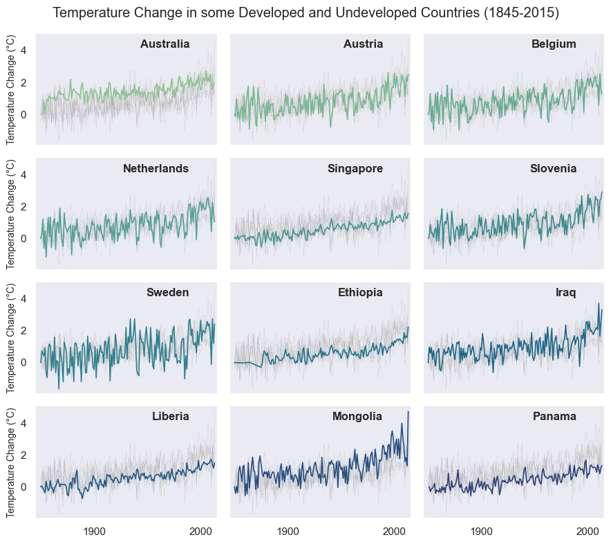

```python
country_df = pd.read_csv("./dataset/mergedinfo.csv")
developed_countries = ['Ireland', 'France', 'Netherlands', 'Belgium', 'Luxembourg', 'Germany', 'Austria', 'Switzerland',
                       'Norway', 'Iceland', 'Denmark', 'Sweden', 'Finland', 'Italy', 'Spain', 'Portugal',
                       'Greece', 'Slovenia', 'Czech Republic', 'Slovak Republic', 'Malta', 'Cyprus', 'United States',
                       'United Kingdom',
                       'Canada', 'New Zealand', 'Poland', 'Australia', 'Japan', 'Singapore', 'South Korea', 'Israel']
undeveloped_countries = list(set(country_df['Name']) - set(developed_countries))
# choose 10 from developed countries and 25 from undeveloped countries
np.random.seed(12)
developed_countries = np.random.choice(developed_countries, 7)
undeveloped_countries = np.random.choice(undeveloped_countries, 6)
oC_data_unde = oC_data[(oC_data['Country'].isin(undeveloped_countries))]
oC_data_de = oC_data[(oC_data['Country'].isin(developed_countries))]
#将两部分合并
oC_data = pd.concat([oC_data_de, oC_data_unde], axis=0)
plt.figure(figsize=(10, 12))
sns.set_theme(style="dark")
# Plot each year's time series in its own facet
g = sns.relplot(
    data=oC_data,
    x="dt", y="AverageTemperature", col="Country", hue="Country",
    kind="line", palette="crest", linewidth=1.2, zorder=5,
    col_wrap=3, height=2, aspect=1.5, legend=False,
)

# Iterate over each subplot to customize further
for year, ax in g.axes_dict.items():
    # Add the title as an annotation within the plot
    ax.text(.85, .95, year, transform=ax.transAxes, fontweight="bold", va="top", ha="right")

    # Plot every year's time series in the background
    sns.lineplot(
        data=oC_data, x="dt", y="AverageTemperature", units="Country",
        estimator=None, color=".7", linewidth=0.15, ax=ax,
    )

# Reduce the frequency of the x axis ticks
ax.set_xticks(ax.get_xticks()[::2])

# Tweak the supporting aspects of the plot
g.set_titles("")
g.set_axis_labels("", "Temperature Change (°C)", fontsize=10)
plt.xlim(1845, 2015)
plt.suptitle('Temperature Change in some Developed and Undeveloped Countries (1845-2015)')
g.tight_layout()
```

在过去的100年间，平均气温上升了1.2度，冰雪融化，海平面上升2.3米，有800万平方公里的草原变成荒漠，且破坏仍将继续，灾难会继续增多。这样重大的气候自然灾害的恶果，不论发达与否，都将饱尝。

```python
real_data = pd.read_csv("./dataset/owid-co2-data.csv")
real_data['year'] = pd.to_datetime(real_data['year'], format="%Y")
real_data = real_data[real_data['year'] >= '1900-01-01']
real_data.drop(['iso_code'], axis=1, inplace=True)
# real_data.head()
```

```python
#data from https://www.kaggle.com/berkeleyearth/climate-change-earth-surface-temperature-data
storm_df = pd.read_excel("./dataset/34个节点风暴潮灾害事件1900-2019.xlsx")
storm_df.head()
#匹配%d/%m/%Y格式或者/%m/%Y格式的日期并存为datatime类型
storm_df['Start date'] = storm_df['Start date'].str.extract(r'(\d{1,2}/\d{1,2}/\d{4}|\d{1,2}/\d{1,2}/\d{2})')
storm_df['Start date'] = pd.to_datetime(storm_df['Start date'], format="%d/%m/%Y")
#在开始日期中只留下年的信息
storm_df['Start date'] = storm_df['Start date'].dt.year
#数据按年排序
storm_df = storm_df.sort_values(by=['Start date'])
#数据每间隔十年计为一类，统计每类的个数，列名为年份信息
storm_df = storm_df.groupby(pd.cut(storm_df['Start date'], np.arange(1900, 2020, 10))).count()
```

```python
df2 = pd.read_csv("./dataset/storm_df.csv")
#give title
pie1 = Pie(init_opts=opts.InitOpts(width="800px", height="500px"), )

pie1.add("", [list(z) for z in zip(df2['Start date'], df2['ISO'])], radius=[0, 200], center=[300, 300],
         label_opts=opts.LabelOpts(font_size=6, font_weight='bold', font_family='Microsoft YaHei', font_style='italic',
                                   color='black', position="outside"), )
# pie1.set_global_opts(title_opts=opts.TitleOpts(title="Storm and Flood Events in 1900-2019",pos_left='center',pos_top='top',title_textstyle_opts=opts.TextStyleOpts(font_size=30,font_weight='bold',color='r')))
pie1.set_global_opts(
    xaxis_opts=opts.AxisOpts(axislabel_opts=opts.LabelOpts(rotate=-15)),
    title_opts=opts.TitleOpts(title='\n\n\n1900-2010年全球风暴和洪水灾害', pos_left="center", pos_right="center")
)
#show
# pie1.render("1900-2010年全球风暴和洪水灾害.html") # 生成html图片
pie1.render_notebook()
```

[output not shown]

地球是人类共同的家园，各国应当同舟共济，尽自己之所能事，维护绿水青山，构建人类命运共同体。**因此，保护地球与减排的任务不应当是各国间推搡的对象，而应当是彼此协作，共同守护的目标**。